# Clase de Proba 167 septiembre

Carlos E Martínez-Rodríguez

17 septiembre, 2025

# Generación de números aleatorios normales

## Generación de 1000 VA normales(0,1)

```r
n1 <- rnorm(1000,0,1); head(n1,20)
```

```
##  [1] -1.65568038 -0.76998430 -1.52582080  0.54386794 -0.33134874 -1.92315056
##  [7] -0.71662969  0.20105105 -1.37368971  2.14864857  0.90117923 -0.24726054
## [13]  0.72729135 -0.99390271  1.78931486  2.64257216  1.21864517 -0.37791572
## [19] -0.08056819 -1.70802611
```

## Generación de 15,000 VA normales(0,1)

```r
n2 <- rnorm(15000,0,1); head(n2,20)
```

```
##  [1]  0.6699176  0.9485020 -1.6190246  0.2749161 -2.0446199  0.9955483
##  [7]  0.1245075 -1.5072062  0.3356746  0.7258951 -0.8498543  1.3466765
## [13]  1.1037884  0.9602963  0.5305335  0.3448790  1.1566237  0.3133445
## [19] -0.7883663 -0.5834853
```

## Generación de 30,000 VA normales(0,1)

```r
n3 <- rnorm(30000,0,1); head(n3,20)
```

```
##  [1]  0.905728153  0.634583899  1.719083719  0.279344365  1.096087671
##  [6]  0.728827147 -0.009771084  0.730093073 -0.372034552  1.527959764
## [11]  0.455574159 -1.080659067 -1.492167904 -0.006147453 -1.087647805
## [16]  0.937559493  0.924837619 -0.995549824 -1.751259826  0.992270423
```

## Grafica de N(0,1)

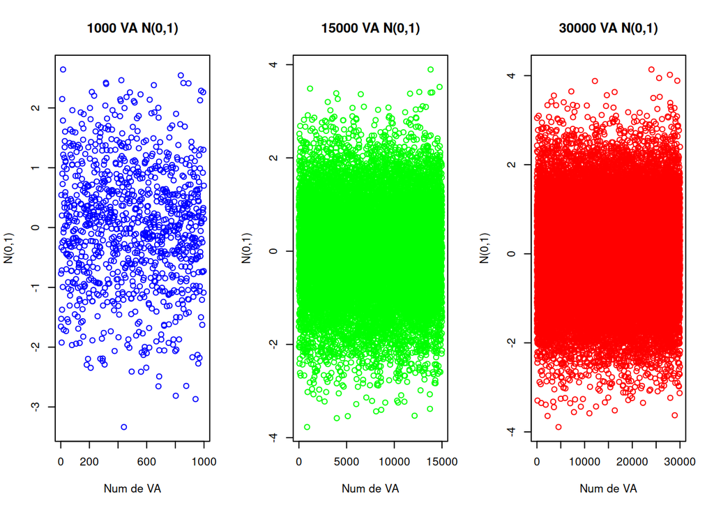

```r
par(mfrow = c(1, 3))
plot(n1,col="blue",
     main = "1000 VA N(0,1)",
     xlab="Num de VA",
     ylab = "N(0,1)")
plot(n2,col="green",
     main = "15000 VA N(0,1)",
     xlab="Num de VA",
     ylab = "N(0,1)")
plot(n3,col="red",
     main = "30000 VA N(0,1)",
     xlab="Num de VA",
     ylab = "N(0,1)")
```

### Grafica mejorada de N(0,1)

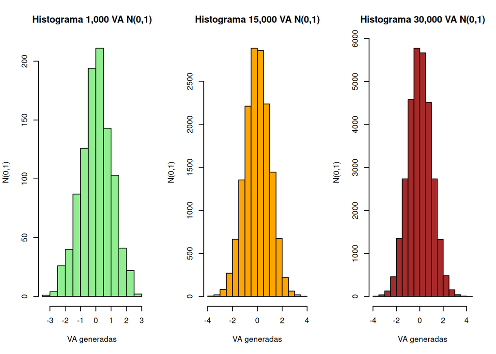

```r
par(mfrow = c(1, 3))
hist(n1,main="Histograma 1,000 VA N(0,1)",
     col = "lightgreen",
     xlab = "VA generadas",
     ylab = "N(0,1)")
hist(n2,main="Histograma 15,000 VA N(0,1)",
     col = "orange",
     xlab = "VA generadas",
     ylab = "N(0,1)")
hist(n3,main="Histograma 30,000 VA N(0,1)",
     col = "brown",
     xlab = "VA generadas",
     ylab = "N(0,1)")
```

### Gráfica de la función de densidad de N(0,1)

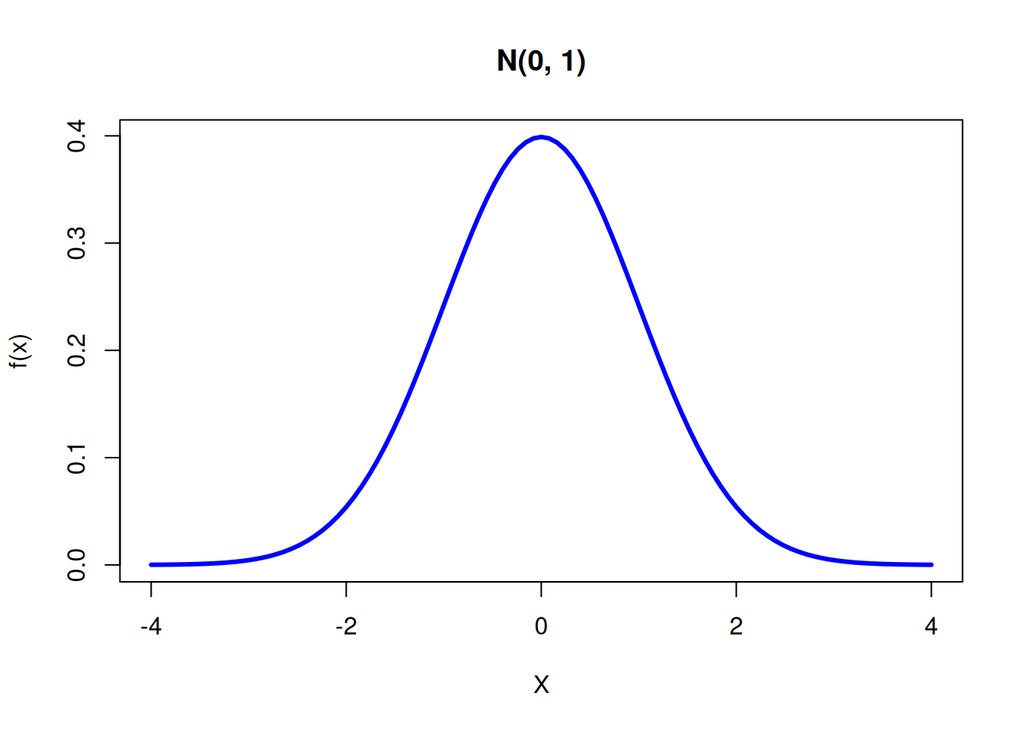

```r
x <- seq(-1, 1, length = 100)
curve(dnorm(x, mean=0, sd=1),
      from=-4, to=4, lwd=3, col="blue",
      main = "N(0, 1)", xlab = "X", ylab = "f(x)")
```

### Comparación de Histogramas para n1, n2, n3

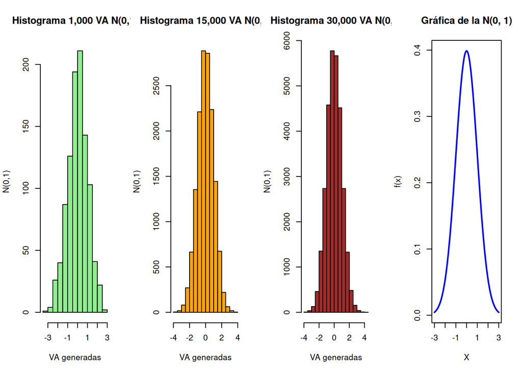

```r
par(mfrow = c(1, 4))
hist(n1,main="Histograma 1,000 VA N(0,1)",
     col = "lightgreen",
     xlab = "VA generadas",
     ylab = "N(0,1)")
hist(n2,main="Histograma 15,000 VA N(0,1)",
     col = "orange",
     xlab = "VA generadas",
     ylab = "N(0,1)")
hist(n3,main="Histograma 30,000 VA N(0,1)",
     col = "brown",
     xlab = "VA generadas",
     ylab = "N(0,1)")
x <- seq(-1, 1, length = 100)
curve(dnorm(x, mean=0, sd=1),
      from=-3, to=3, lwd=2, col="blue",
      main = "Gráfica de la N(0, 1)", xlab = "X", ylab = "f(x)")
```

### Comparación de histogramas de n1,n2,n3,n4,n5 y n6

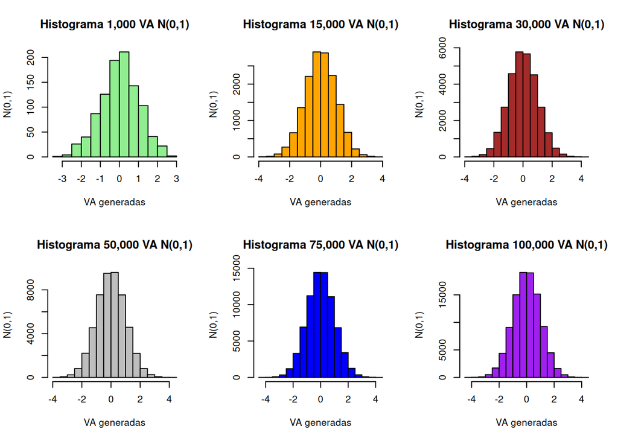

```r
n4 <- rnorm(50000,0,1);
n5 <- rnorm(75000,0,1);
n6 <- rnorm(100000,0,1);
par(mfrow = c(2, 3))
hist(n1,main="Histograma 1,000 VA N(0,1)",
     col = "lightgreen",
     xlab = "VA generadas",ylab = "N(0,1)")
hist(n2,main="Histograma 15,000 VA N(0,1)",
     col = "orange",
     xlab = "VA generadas",ylab = "N(0,1)")
hist(n3,main="Histograma 30,000 VA N(0,1)",
     col = "brown",
     xlab = "VA generadas",ylab = "N(0,1)")
hist(n4,main="Histograma 50,000 VA N(0,1)",
     col = "gray",
     xlab = "VA generadas",ylab = "N(0,1)")
hist(n5,main="Histograma 75,000 VA N(0,1)",
     col = "blue",
     xlab = "VA generadas",ylab = "N(0,1)")
hist(n6,main="Histograma 100,000 VA N(0,1)",
     col = "purple",
     xlab = "VA generadas",ylab = "N(0,1)")
```

## Grafica de Normales N(-1,1)

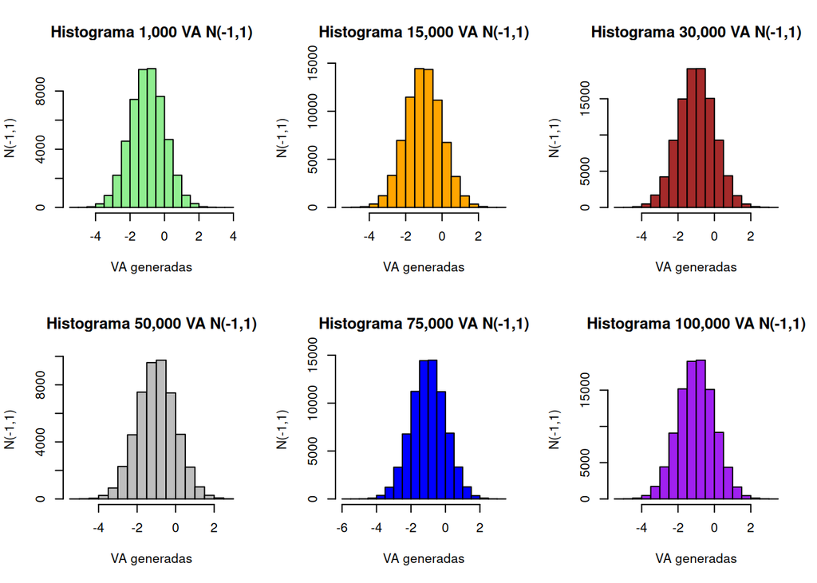

```r
n1 <- rnorm(50000,-1,1);
n2 <- rnorm(75000,-1,1);
n3 <- rnorm(100000,-1,1);
n4 <- rnorm(50000,-1,1);
n5 <- rnorm(75000,-1,1);
n6 <- rnorm(100000,-1,1);
par(mfrow = c(2, 3))
hist(n1,main="Histograma 1,000 VA N(-1,1)",
     col = "lightgreen",
     xlab = "VA generadas",ylab = "N(-1,1)")
hist(n2,main="Histograma 15,000 VA N(-1,1)",
     col = "orange",
     xlab = "VA generadas",ylab = "N(-1,1)")
hist(n3,main="Histograma 30,000 VA N(-1,1)",
     col = "brown",
     xlab = "VA generadas",ylab = "N(-1,1)")
hist(n4,main="Histograma 50,000 VA N(-1,1)",
     col = "gray",
     xlab = "VA generadas",ylab = "N(-1,1)")
hist(n5,main="Histograma 75,000 VA N(-1,1)",
     col = "blue",
     xlab = "VA generadas",ylab = "N(-1,1)")
hist(n6,main="Histograma 100,000 VA N(-1,1)",
     col = "purple",
     xlab = "VA generadas",ylab = "N(-1,1)")
```

## Grafica de Normales N(0,2)

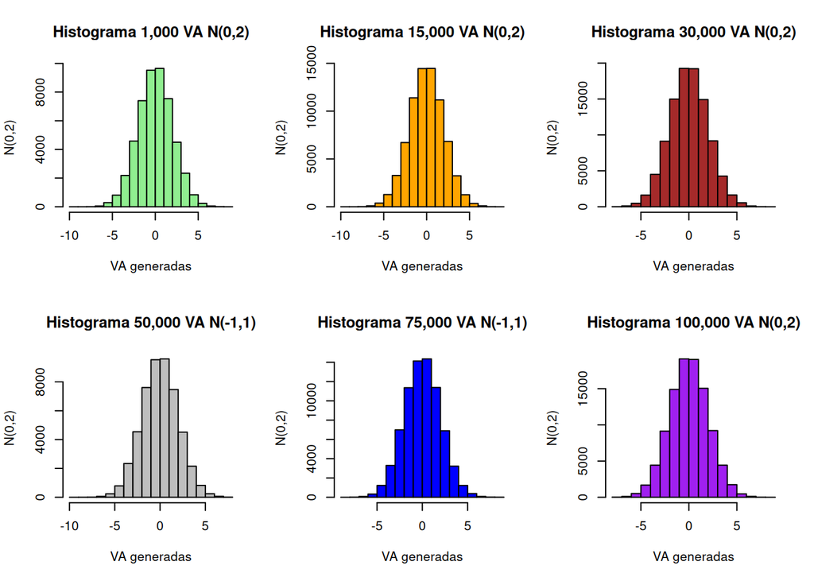

```r
n1 <- rnorm(50000,0,2);
n2 <- rnorm(75000,0,2);
n3 <- rnorm(100000,0,2);
n4 <- rnorm(50000,0,2);
n5 <- rnorm(75000,0,2);
n6 <- rnorm(100000,0,2);
par(mfrow = c(2, 3))
hist(n1,main="Histograma 1,000 VA N(0,2)",
     col = "lightgreen",
     xlab = "VA generadas",ylab = "N(0,2)")
hist(n2,main="Histograma 15,000 VA N(0,2)",
     col = "orange",
     xlab = "VA generadas",ylab = "N(0,2)")
hist(n3,main="Histograma 30,000 VA N(0,2)",
     col = "brown",
     xlab = "VA generadas",ylab = "N(0,2)")
hist(n4,main="Histograma 50,000 VA N(-1,1)",
     col = "gray",
     xlab = "VA generadas",ylab = "N(0,2)")
hist(n5,main="Histograma 75,000 VA N(-1,1)",
     col = "blue",
     xlab = "VA generadas",ylab = "N(0,2)")
hist(n6,main="Histograma 100,000 VA N(0,2)",
     col = "purple",
     xlab = "VA generadas",ylab = "N(0,2)")
```

## Grafica de Normales N(mu,sigma^2)

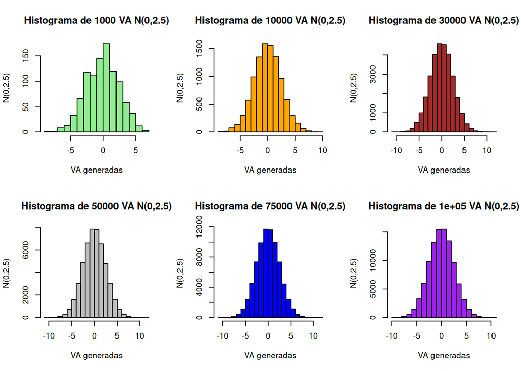

```r
media <- 0
desvstd <- 2.5
q1 <- 1000; q2 <- 10000; q3 <- 30000;
q4 <- 50000; q5 <- 75000; q6 <- 100000
n1 <- rnorm(q1,media,desvstd);
n2 <- rnorm(q2,media,desvstd);
n3 <- rnorm(q3,media,desvstd);
n4 <- rnorm(q4,media,desvstd);
n5 <- rnorm(q5,media,desvstd);
n6 <- rnorm(q6,media,desvstd);
mititulo1 <- paste0("Histograma de ",q1," VA N(",media,",",desvstd,")")
mititulo2 <- paste0("Histograma de ",q2," VA N(",media,",",desvstd,")")
mititulo3 <- paste0("Histograma de ",q3," VA N(",media,",",desvstd,")")
mititulo4 <- paste0("Histograma de ",q4," VA N(",media,",",desvstd,")")
mititulo5 <- paste0("Histograma de ",q5," VA N(",media,",",desvstd,")")
mititulo6 <- paste0("Histograma de ",q6," VA N(",media,",",desvstd,")")
etiquetay <- paste0("N(",media,",",desvstd,")")

par(mfrow = c(2, 3))
hist(n1,main=mititulo1,
     col = "lightgreen",
     xlab = "VA generadas",ylab = etiquetay)
hist(n2,main=mititulo2,
     col = "orange",
     xlab = "VA generadas",ylab = etiquetay)
hist(n3,main=mititulo3,
     col = "brown",
     xlab = "VA generadas",ylab = etiquetay)
hist(n4,main=mititulo4,
     col = "gray",
     xlab = "VA generadas",ylab = etiquetay)
hist(n5,main=mititulo5,
     col = "blue",
     xlab = "VA generadas",ylab = etiquetay)
hist(n6,main=mititulo6,
     col = "purple",
     xlab = "VA generadas",ylab = etiquetay)
```

## Grafica de histogramas y pdf

```r
library(MASS)
set.seed(1)
q1 <- 1000; q2 <- 10000; q3 <- 30000;
q4 <- 50000; q5 <- 75000; q6 <- 100000
media <- 0; desvstd <- 2.5
mititulo <- paste0()
n1 <- rnorm(q1,media,desvstd);
n2 <- rnorm(q2,media,desvstd);
n3 <- rnorm(q3,media,desvstd);
n4 <- rnorm(q4,media,desvstd);
n5 <- rnorm(q5,media,desvstd);
n6 <- rnorm(q6,media,desvstd);
mititulo1 <- paste0("Histograma y densidad de ",q1," VA N(",media,",",desvstd,")")
mititulo2 <- paste0("Histograma y densidad de ",q2," VA N(",media,",",desvstd,")")
mititulo3 <- paste0("Histograma y densidad de ",q3," VA N(",media,",",desvstd,")")
mititulo4 <- paste0("Histograma y densidad de ",q4," VA N(",media,",",desvstd,")")
mititulo5 <- paste0("Histograma y densidad de ",q5," VA N(",media,",",desvstd,")")
mititulo6 <- paste0("Histograma y densidad de ",q6," VA N(",media,",",desvstd,")")

par(mfrow = c(2, 3))
fit1 <- fitdistr(n1, "normal")
fit1
```

```
##       mean           sd
##   -0.02912035    2.58599563
##  ( 0.08177636) ( 0.05782462)
```

```r
hist(n1,
     freq = FALSE,
     col = "lightblue",
     border = "black",
     main = mititulo1,
     xlab = "",
     ylab = "Densidad")

curve(dnorm(x,
            mean = fit1$estimate["mean"],
            sd   = fit1$estimate["sd"]),
      from = min(n1), to=max(n1),
      add = TRUE,
      lwd = 3,
      col = "tomato")

lines(density(n1), lwd = 2)
legend("topleft",
       legend = c("Ajuste", "Empírica"),
       lwd = c(3,2), col = c("tomato","black"), bty = "n")

fit2 <- fitdistr(n2, "normal")
fit2
```

```
##       mean           sd
##   -0.01347737    2.50746652
##  ( 0.02507467) ( 0.01773047)
```

```r
hist(n2,
     freq = FALSE,
     col = "yellow",
     border = "black",
     main = "Histograma y densidad ajustada",
     xlab = "",
     ylab = "Densidad")

curve(dnorm(x,
            mean = fit2$estimate["mean"],
            sd   = fit2$estimate["sd"]),
      from = min(n2), to=max(n2),
      add = TRUE,
      lwd = 3,
      col = "tomato")

lines(density(n2), lwd = 2)
legend("topleft",
       legend = c("Ajuste", "Empírica"),
       lwd = c(3,2), col = c("tomato","black"), bty = "n")


fit3 <- fitdistr(n3, "normal")
fit3
```

```
##        mean            sd
##   -0.001523952    2.501721137
##  ( 0.014443694) ( 0.010213234)
```

```r
hist(n3,
     freq = FALSE,
     col = "cyan",
     border = "black",
     main = "Histograma y densidad ajustada",
     xlab = "",
     ylab = "Densidad")

curve(dnorm(x,
            mean = fit3$estimate["mean"],
            sd   = fit3$estimate["sd"]),
      from = min(n1), to=max(n1),
      add = TRUE,
      lwd = 3,
      col = "tomato")

lines(density(n3), lwd = 2)
legend("topleft",
       legend = c("Ajuste", "Empírica"),
       lwd = c(3,2), col = c("tomato","black"), bty = "n")

fit4 <- fitdistr(n4, "normal")
fit4
```

```
##        mean            sd
##   -0.008013974    2.508455664
##  ( 0.011218155) ( 0.007932433)
```

```r
hist(n4,
     freq = FALSE,
     col = "brown",
     border = "black",
     main = "Histograma y densidad ajustada",
     xlab = "",
     ylab = "Densidad")

curve(dnorm(x,
            mean = fit4$estimate["mean"],
            sd   = fit4$estimate["sd"]),
      from = min(n4), to=max(n4),
      add = TRUE,
      lwd = 3,
      col = "tomato")

lines(density(n4), lwd = 2)
legend("topleft",
       legend = c("Ajuste", "Empírica"),
       lwd = c(3,2), col = c("tomato","black"), bty = "n")

fit5 <- fitdistr(n5, "normal")
fit5
```

```
##       mean           sd
##   0.004684415   2.511007608
##  (0.009168903) (0.006483394)
```

```r
hist(n5,
     freq = FALSE,
     col = "lightgreen",
     border = "black",
     main = "Histograma y densidad ajustada",
     xlab = "",
     ylab = "Densidad")

curve(dnorm(x,
            mean = fit5$estimate["mean"],
            sd   = fit5$estimate["sd"]),
      from = min(n5), to=max(n5),
      add = TRUE,
      lwd = 3,
      col = "tomato")

lines(density(n5), lwd = 2)
legend("topleft",
       legend = c("Ajuste", "Empírica"),
       lwd = c(3,2), col = c("tomato","black"), bty = "n")

fit6 <- fitdistr(n6, "normal")
fit6
```

```
##        mean            sd
##   -0.002780465    2.494116478
##  ( 0.007887089) ( 0.005577014)
```

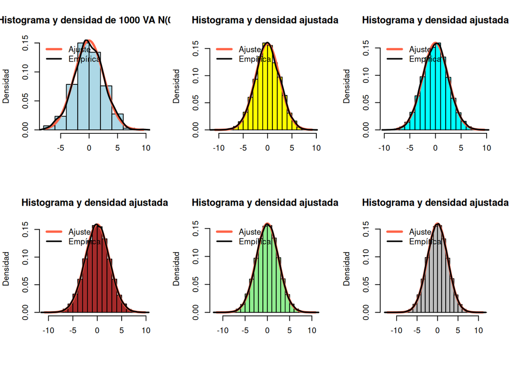

```r
hist(n6,
     freq = FALSE,
     col = "gray",
     border = "black",
     main = "Histograma y densidad ajustada",
     xlab = "",
     ylab = "Densidad")

curve(dnorm(x,
            mean = fit6$estimate["mean"],
            sd   = fit6$estimate["sd"]),
      from = min(n6), to=max(n6),
      add = TRUE,
      lwd = 3,
      col = "tomato")

lines(density(n6), lwd = 2)
legend("topleft",
       legend = c("Ajuste", "Empírica"),
       lwd = c(3,2), col = c("tomato","black"), bty = "n")
```

# Distribución Exponencial

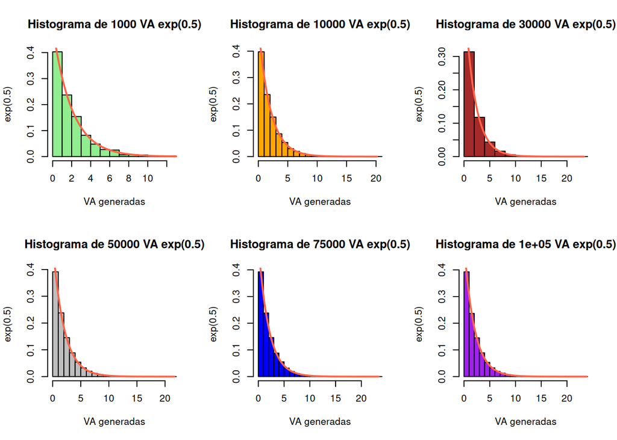

```r
lambda <- 0.5
q1 <- 1000; q2 <- 10000; q3 <- 30000;
q4 <- 50000; q5 <- 75000; q6 <- 100000
n1 <- rexp(q1,lambda);
n2 <- rexp(q2,lambda);
n3 <- rexp(q3,lambda);
n4 <- rexp(q4,lambda);
n5 <- rexp(q5,lambda);
n6 <- rexp(q6,lambda);

mititulo1 <- paste0("Histograma de ",q1," VA exp(",lambda,")")
mititulo2 <- paste0("Histograma de ",q2," VA exp(",lambda,")")
mititulo3 <- paste0("Histograma de ",q3," VA exp(",lambda,")")
mititulo4 <- paste0("Histograma de ",q4," VA exp(",lambda,")")
mititulo5 <- paste0("Histograma de ",q5," VA exp(",lambda,")")
mititulo6 <- paste0("Histograma de ",q6," VA exp(",lambda,")")
etiquetay <- paste0("exp(",lambda,")")

par(mfrow = c(2, 3))
hist(n1,main=mititulo1,
     freq = FALSE,
     col = "lightgreen",
     xlab = "VA generadas",ylab = etiquetay)
curve(dexp(x, rate = lambda),
      from = 0, to = max(n1),
      add = TRUE, col = "tomato", lwd = 2)

hist(n2,main=mititulo2,
     freq = FALSE,
     col = "orange",
     xlab = "VA generadas",ylab = etiquetay)
curve(dexp(x, rate = lambda),
      from = 0, to = max(n2),
      add = TRUE, col = "tomato", lwd = 2)

hist(n3,main=mititulo3,
     freq = FALSE,
     col = "brown",
     xlab = "VA generadas",ylab = etiquetay)
curve(dexp(x, rate = lambda),
      from = 0, to = max(n3),
      add = TRUE, col = "tomato", lwd = 2)

hist(n4,main=mititulo4,
     freq = FALSE,
     col = "gray",
     xlab = "VA generadas",ylab = etiquetay)
curve(dexp(x, rate = lambda),
      from = 0, to = max(n4),
      add = TRUE, col = "tomato", lwd = 2)

hist(n5,main=mititulo5,
     freq = FALSE,
     col = "blue",
     xlab = "VA generadas",ylab = etiquetay)
curve(dexp(x, rate = lambda),
      from = 0, to = max(n5),
      add = TRUE, col = "tomato", lwd = 2)



hist(n6,main=mititulo6,
     freq = FALSE,
     col = "purple",
     xlab = "VA generadas",ylab = etiquetay)
curve(dexp(x, rate = lambda),
      from = 0, to = max(n6),
      add = TRUE, col = "tomato", lwd = 2)
```

“Binomial” = rbinom(input$nvar, input$n, input$p), "Poisson" = rpois(input$nvar, input$lambda), "Geométrica" = rgeom(input$nvar, input$p), "Exponencial" = rexp(input$nvar, input$lambda), "Normal" = rnorm(input$nvar, input$mu, input$sd), “Gamma” = rgamma(input$nvar, input$alpha, input$beta), "Beta" = rbeta(input$nvar, input$alpha, input$beta), “T-Student” = rt(input$nvar, input$alpha)

dnorm(x, # Valores del eje X (rejilla) mean = 0, # Número o vector representando la/s media/s sd = 1, # Número o vector representando la/s desviación/es típica/s log = FALSE) # Si TRUE, las probabilidades se devuelven como logaritmos

# Por incluir en clase

x <- -4:4 # x <- seq(-4, 4, length = 100) # Más observaciones dnorm(x, mean = 1, sd = 3)

dnorm(x, mean = c(1, 2), sd = c(3, 4))

par(mfrow = c(1, 2))

## Rejilla de valores para el eje X

x <- seq(-4, 8, 0.1)

#—————————————– # Misma desviación típica, distinta media #—————————————– # Media 0, desviación típica 1 plot(x, dnorm(x, mean = 0, sd = 1), type = “l”, ylim = c(0, 0.6), ylab = ““, lwd = 2, col =”red”) # Media 3, desviación típica 1 lines(x, dnorm(x, mean = 3, sd = 1), col = “blue”, lty = 1, lwd = 2)

# Añadimos una leyenda

legend(“topright”, c(expression(paste(, mu, ” “, sigma)),”0 1”, “3 1”), lty = c(0, 1, 1), col = c(“blue”, “red”), box.lty = 0, lwd = 2)

#—————————————– # Misma media, distinta desviación típica #—————————————– # Media 1, desviación típica 1 plot(x, dnorm(x, mean = 1, sd = 1), type = “l”, ylim = c(0, 1), ylab = ““, lwd = 2, col =”red”) # Media 1, desviación típica 0.5 lines(x, dnorm(x, mean = 1, sd = 0.5), col = “blue”, lty = 1, lwd = 2)

# Añadimos una leyenda

legend(“topright”, c(expression(paste(, mu, ” “, sigma)),”1 1”, “1 0.5”), lty = c(0, 1, 1), col = c(“blue”, “red”), box.lty = 0, lwd = 2)

par(mfrow = c(1, 1))

# Media y desviación típica

mu <- 1000 sigma <- 10

# Grid para una distribución normal no estándar

x <- seq(-3, 3, length = 100) * sigma + mu

# Función de densidad

f <- dnorm(x, mu, sigma)

plot(x, f, type = “l”, lwd = 2, col = “blue”, ylab = ““, xlab =”Weight”) abline(v = mu) # Línea vertical en la media

lb <- min(x) # Límite inferior ub <- 1010 # Límite superior

x2 <- seq(min(x), ub, length = 100) # Nueva rejilla y <- dnorm(x2, mu, sigma) # Densidad

plot(x, f, type = “l”, lwd = 2, col = “blue”, ylab = ““, xlab =”Peso”) abline(v = ub)

polygon(c(lb, x2, ub), c(0, y, 0), col = rgb(0, 0, 1, alpha = 0.5)) text(995, 0.01, “84.13%”)

# mean: media de la variable normal

# sd: desviación típica de la variable normal

# lb: límite inferior del área

# ub: límite superior del área

# acolor: color del área

# …: argumentos adicionales para ser pasados a la función lines

normal_area <- function(mean = 0, sd = 1, lb, ub, acolor = “lightgray”, …) { x <- seq(mean - 3 * sd, mean + 3 * sd, length = 100)

```
if (missing(lb)) {
   lb <- min(x)
}
if (missing(ub)) {
    ub <- max(x)
}

x2 <- seq(lb, ub, length = 100)
plot(x, dnorm(x, mean, sd), type = "n", ylab = "")

y <- dnorm(x2, mean, sd)
polygon(c(lb, x2, ub), c(0, y, 0), col = acolor)
lines(x, dnorm(x, mean, sd), type = "l", ...)
```

}

normal_area(mean = mu, sd = sigma, lb = 980, acolor = rgb(0, 0, 1, alpha = 0.5)) text(1000, 0.01, “97.72%”)

normal_area(mean = mu, sd = sigma, lb = 990, ub = 1000, acolor = rgb(0, 0, 1, alpha = 0.5)) text(995, 0.01, “34.13%”, srt = 90)

par(mfrow = c(1, 2))

# Rejilla de valores para el eje X

x <- seq(-4, 8, 0.1)

#—————————————– # Misma desviación típica, distinta media #—————————————– # Media 0, desviación típica 1 plot(x, pnorm(x, mean = 0, sd = 1), type = “l”, ylim = c(0, 1), ylab = ““, lwd = 2, col =”red”) # Media 3, desviación típica 1 lines(x, pnorm(x, mean = 3, sd = 1), col = “blue”, lty = 1, lwd = 2)

# Leyenda

legend(“topleft”, c(expression(paste(, mu, ” “, sigma)),”0 1”, “3 1”), lty = c(0, 1, 1), col = c(“blue”, “red”), box.lty = 0, lwd = 2)

#—————————————– # Misma media, distinta desviación típica #—————————————– # Media 1, desviación típica 1 plot(x, pnorm(x, mean = 1, sd = 1), type = “l”, ylim = c(0, 1), ylab = ““, lwd = 2, col =”red”) # Media 0, desviación típica 0.5 lines(x, pnorm(x, mean = 1, sd = 0.5), col = “blue”, lty = 1, lwd = 2)

# Leyenda

legend(“topleft”, c(expression(paste(, mu, ” “, sigma)),”1 1”, “1 0.5”), lty = c(0, 1, 1), col = c(“blue”, “red”), box.lty = 0, lwd = 2)

par(mfrow = c(1, 1))

x <- seq(-4, 4, 0.1) plot(x, pnorm(x, mean = 0, sd = 1), type = “l”, ylim = c(0, 1), ylab = “P(X < x)”, lwd = 2, col = “red”) segments(0, 0, 0, 0.5, lwd = 2, lty = 2) segments(-4, 0.5, 0, 0.5, lwd = 2, lty = 2)

x <- pnorm(-1.5, mean = 0, sd = 1) # 0.0668072 qnorm(x, mean = 0, sd = 1) # -1.5

qnorm(p, # Número o vector de probabilidades mean = 0, # Número o vector representando la/s media/s sd = 1, # Número o vector representando la/s desviación/es típica/s lower.tail = TRUE, # Si TRUE, las probabilidades son P(X <= x), o P(X > x) si FALSE log.p = FALSE) # Si TRUE, las probabilidades vienen dadas como logaritmos

normal_area(mean = 0, sd = 1, ub = -1.5, lwd = 2, acolor = rgb(0, 0, 1, alpha = 0.5)) arrows(-0.5, 0.1, -1.45, 0, lwd = 2, length = 0.2) text(-0.25, 0.13, “-1.5”, cex = 1.5)